# Industry 4.0 의 중심, BigData

Data Processing Based Python @ [FB / jskim.kr](https://www.facebook.com/jskim.kr), [김진수](bigpycraft@gmail.com)

# NumPy Basics 2

```python
from images import bigpycraft_bda as bpc
from IPython.display import Image
from numpy.random import randn
import numpy as np
```

## 2. Universal Functions: Fast element-wise array functions

> 유니버설 함수
> - ufunc라고 불리는 유니버설 함수는 ndarray 안에 있는 데이터 원소별로 연산을 수행하는 함수다.
> - 하나 이상의 스칼라 값을 받아서 하나 이상의 스칼라 결과 값을 반환하는 간단한 함수를 고속으로 수행할 수 있는 벡터화된 래퍼 함수
> - 많은 ufunc는 sqrt나 exp 같은 간단한 변형을 전체 원소에 적용할 수 있다.

> np.random
> - random.randint 와 np.random.randint : 모두 (시작, n-1) 사이의 랜덤숫자 1개 뽑아내기
> - np.random.rand(m, n) : 0~1의 균일분포 표준정규분포 난수를 matrix array(m, n) 생성
> - np.random.randn(m, n) : 평균0, 표준편차1의 가우시안 표준정규분포 난수를 matrix array(m, n) 생성

```python
arr = np.arange(10)
arr
```

```
array([0, 1, 2, 3, 4, 5, 6, 7, 8, 9])
```

```python
np.sqrt(arr)
```

```
array([0.        , 1.        , 1.41421356, 1.73205081, 2.        ,
       2.23606798, 2.44948974, 2.64575131, 2.82842712, 3.        ])
```

```python
np.exp(arr)
```

```
array([1.00000000e+00, 2.71828183e+00, 7.38905610e+00, 2.00855369e+01,
       5.45981500e+01, 1.48413159e+02, 4.03428793e+02, 1.09663316e+03,
       2.98095799e+03, 8.10308393e+03])
```

```python
x = randn(8)
x
```

```
array([ 1.62065039, -1.80659987, -0.38160524, -1.87143572, -0.97502963,
        1.02684417,  0.04286994, -2.10222408])
```

```python
y = randn(8)
y
```

```
array([-0.21698505,  1.42964476,  1.23530307,  1.12995186,  0.56221509,
       -1.21376124,  0.37784788,  0.6938382 ])
```

```python
np.maximum(x, y) # element-wise maximum
```

```
array([1.62065039, 1.42964476, 1.23530307, 1.12995186, 0.56221509,
       1.02684417, 0.37784788, 0.6938382 ])
```

```python
arr = randn(7) * 5
arr
```

```
array([-2.71182911,  4.37799162,  6.10174343, -1.06737074, -7.34503152,
       -0.19065391, -7.15451017])
```

- modf는 실수파트와 정수파트를 함께 반환

```python
np.modf(arr)
```

```
(array([-0.71182911,  0.37799162,  0.10174343, -0.06737074, -0.34503152,
        -0.19065391, -0.15451017]), array([-2.,  4.,  6., -1., -7., -0., -7.]))
```

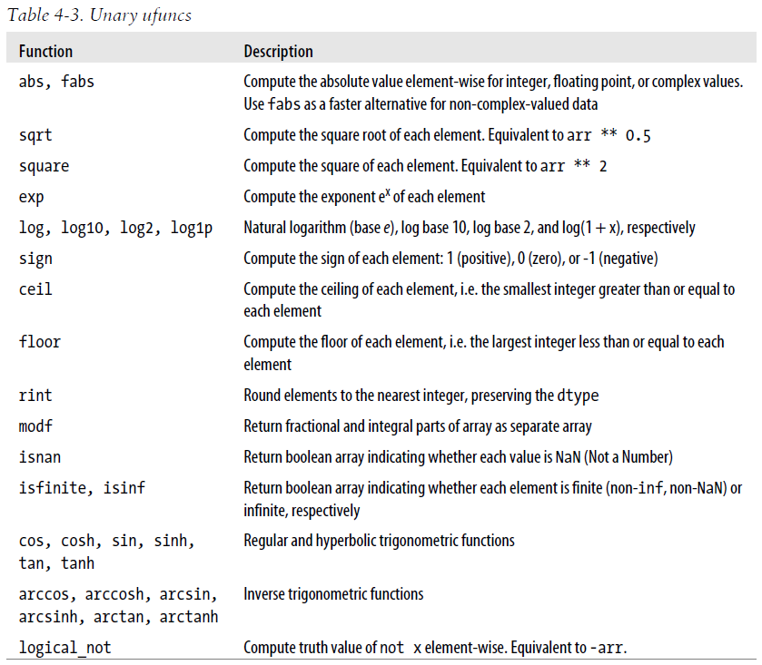

```python
# 참고. 단항 유니버설 함수
Image(bpc.Table4_3)
```

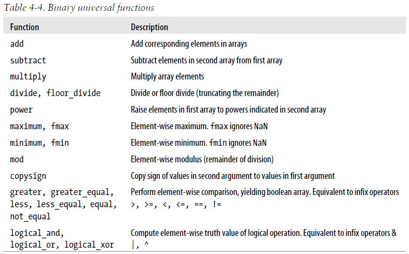

```python
# 참고. 이항 유니버설 함수
Image(bpc.Table4_4)
```

## 3. Data processing using arrays

> 배열을 사용한 데이터 처리
> - NupPy 배열을 사용하면 반복문을 작성하지 않고 간결한 배열연산을 통해 많은 종류의 데이터 처리 작업 가능
> - 벡터화 : 배열연산을 사용해서 반복문을 명시적으로 제거하는 기법
> - 일반적으로 벡터화된 배열에 대한 산술연산은 순수 파이썬 연산에 비애 2~3배, 많게는 수백배까지 빠름

Eg. 그리드에서 sqrt(x^2 + y^2) 계산 :: np.meshgrid 함수는 2개의 1차원 배열을 받아 가능한 한 모든 (x, y)짝을 만들 수 있는 2차원 배열 2개를 반환

```python
points = np.arange(-5, 5, 0.01) # 1000 equally spaced points
points
```

```
array([-5.0000000e+00, -4.9900000e+00, -4.9800000e+00, -4.9700000e+00,
       -4.9600000e+00, -4.9500000e+00, -4.9400000e+00, -4.9300000e+00,
       -4.9200000e+00, -4.9100000e+00, -4.9000000e+00, -4.8900000e+00,
       -4.8800000e+00, -4.8700000e+00, -4.8600000e+00, -4.8500000e+00,
       -4.8400000e+00, -4.8300000e+00, -4.8200000e+00, -4.8100000e+00,
       -4.8000000e+00, -4.7900000e+00, -4.7800000e+00, -4.7700000e+00,
       -4.7600000e+00, -4.7500000e+00, -4.7400000e+00, -4.7300000e+00,
       -4.7200000e+00, -4.7100000e+00, -4.7000000e+00, -4.6900000e+00,
       -4.6800000e+00, -4.6700000e+00, -4.6600000e+00, -4.6500000e+00,
       -4.6400000e+00, -4.6300000e+00, -4.6200000e+00, -4.6100000e+00,
       -4.6000000e+00, -4.5900000e+00, -4.5800000e+00, -4.5700000e+00,
       -4.5600000e+00, -4.5500000e+00, -4.5400000e+00, -4.5300000e+00,
       -4.5200000e+00, -4.5100000e+00, -4.5000000e+00, -4.4900000e+00,
       -4.4800000e+00, -4.4700000e+00, -4.4600000e+00, -4.4500000e+00,
       -4.4400000e+00, -4.4300000e+00, -4.4200000e+00, -4.4100000e+00,
       -4.4000000e+00, -4.3900000e+00, -4.3800000e+00, -4.3700000e+00,
       -4.3600000e+00, -4.3500000e+00, -4.3400000e+00, -4.3300000e+00,
       -4.3200000e+00, -4.3100000e+00, -4.3000000e+00, -4.2900000e+00,
       -4.2800000e+00, -4.2700000e+00, -4.2600000e+00, -4.2500000e+00,
       -4.2400000e+00, -4.2300000e+00, -4.2200000e+00, -4.2100000e+00,
       -4.2000000e+00, -4.1900000e+00, -4.1800000e+00, -4.1700000e+00,
       -4.1600000e+00, -4.1500000e+00, -4.1400000e+00, -4.1300000e+00,
       -4.1200000e+00, -4.1100000e+00, -4.1000000e+00, -4.0900000e+00,
       -4.0800000e+00, -4.0700000e+00, -4.0600000e+00, -4.0500000e+00,
       -4.0400000e+00, -4.0300000e+00, -4.0200000e+00, -4.0100000e+00,
       -4.0000000e+00, -3.9900000e+00, -3.9800000e+00, -3.9700000e+00,
       -3.9600000e+00, -3.9500000e+00, -3.9400000e+00, -3.9300000e+00,
       -3.9200000e+00, -3.9100000e+00, -3.9000000e+00, -3.8900000e+00,
       -3.8800000e+00, -3.8700000e+00, -3.8600000e+00, -3.8500000e+00,
       -3.8400000e+00, -3.8300000e+00, -3.8200000e+00, -3.8100000e+00,
       -3.8000000e+00, -3.7900000e+00, -3.7800000e+00, -3.7700000e+00,
       -3.7600000e+00, -3.7500000e+00, -3.7400000e+00, -3.7300000e+00,
       -3.7200000e+00, -3.7100000e+00, -3.7000000e+00, -3.6900000e+00,
       -3.6800000e+00, -3.6700000e+00, -3.6600000e+00, -3.6500000e+00,
       -3.6400000e+00, -3.6300000e+00, -3.6200000e+00, -3.6100000e+00,
       -3.6000000e+00, -3.5900000e+00, -3.5800000e+00, -3.5700000e+00,
       -3.5600000e+00, -3.5500000e+00, -3.5400000e+00, -3.5300000e+00,
       -3.5200000e+00, -3.5100000e+00, -3.5000000e+00, -3.4900000e+00,
       -3.4800000e+00, -3.4700000e+00, -3.4600000e+00, -3.4500000e+00,
       -3.4400000e+00, -3.4300000e+00, -3.4200000e+00, -3.4100000e+00,
```

[output cut: 195 more lines]

```
        4.4000000e+00,  4.4100000e+00,  4.4200000e+00,  4.4300000e+00,
        4.4400000e+00,  4.4500000e+00,  4.4600000e+00,  4.4700000e+00,
        4.4800000e+00,  4.4900000e+00,  4.5000000e+00,  4.5100000e+00,
        4.5200000e+00,  4.5300000e+00,  4.5400000e+00,  4.5500000e+00,
        4.5600000e+00,  4.5700000e+00,  4.5800000e+00,  4.5900000e+00,
        4.6000000e+00,  4.6100000e+00,  4.6200000e+00,  4.6300000e+00,
        4.6400000e+00,  4.6500000e+00,  4.6600000e+00,  4.6700000e+00,
        4.6800000e+00,  4.6900000e+00,  4.7000000e+00,  4.7100000e+00,
        4.7200000e+00,  4.7300000e+00,  4.7400000e+00,  4.7500000e+00,
        4.7600000e+00,  4.7700000e+00,  4.7800000e+00,  4.7900000e+00,
        4.8000000e+00,  4.8100000e+00,  4.8200000e+00,  4.8300000e+00,
        4.8400000e+00,  4.8500000e+00,  4.8600000e+00,  4.8700000e+00,
        4.8800000e+00,  4.8900000e+00,  4.9000000e+00,  4.9100000e+00,
        4.9200000e+00,  4.9300000e+00,  4.9400000e+00,  4.9500000e+00,
        4.9600000e+00,  4.9700000e+00,  4.9800000e+00,  4.9900000e+00])
```

```python
xs, ys = np.meshgrid(points, points)
```

```python
xs
```

```
array([[-5.  , -4.99, -4.98, ...,  4.97,  4.98,  4.99],
       [-5.  , -4.99, -4.98, ...,  4.97,  4.98,  4.99],
       [-5.  , -4.99, -4.98, ...,  4.97,  4.98,  4.99],
       ...,
       [-5.  , -4.99, -4.98, ...,  4.97,  4.98,  4.99],
       [-5.  , -4.99, -4.98, ...,  4.97,  4.98,  4.99],
       [-5.  , -4.99, -4.98, ...,  4.97,  4.98,  4.99]])
```

```python
ys
```

```
array([[-5.  , -5.  , -5.  , ..., -5.  , -5.  , -5.  ],
       [-4.99, -4.99, -4.99, ..., -4.99, -4.99, -4.99],
       [-4.98, -4.98, -4.98, ..., -4.98, -4.98, -4.98],
       ...,
       [ 4.97,  4.97,  4.97, ...,  4.97,  4.97,  4.97],
       [ 4.98,  4.98,  4.98, ...,  4.98,  4.98,  4.98],
       [ 4.99,  4.99,  4.99, ...,  4.99,  4.99,  4.99]])
```

```python
from matplotlib.pyplot import imshow, title
import matplotlib.pyplot as plt
```

```python
z = np.sqrt(xs ** 2 + ys ** 2)
z
```

```
array([[7.07106781, 7.06400028, 7.05693985, ..., 7.04988652, 7.05693985,
        7.06400028],
       [7.06400028, 7.05692568, 7.04985815, ..., 7.04279774, 7.04985815,
        7.05692568],
       [7.05693985, 7.04985815, 7.04278354, ..., 7.03571603, 7.04278354,
        7.04985815],
       ...,
       [7.04988652, 7.04279774, 7.03571603, ..., 7.0286414 , 7.03571603,
        7.04279774],
       [7.05693985, 7.04985815, 7.04278354, ..., 7.03571603, 7.04278354,
        7.04985815],
       [7.06400028, 7.05692568, 7.04985815, ..., 7.04279774, 7.04985815,
        7.05692568]])
```

```python
plt.imshow(z, cmap=plt.cm.gray);
plt.colorbar()
```

[output not shown]

```python
plt.title("Image plot of $\sqrt{x^2 + y^2}$ for a grid of values")
```

```
Text(0.5,1,'Image plot of $\\sqrt{x^2 + y^2}$ for a grid of values')
```

```python
plt.imshow(z, cmap=plt.cm.gray);
plt.colorbar()
plt.title("Image plot of $\sqrt{x^2 + y^2}$ for a grid of values")
plt.draw()
```

[output not shown]

### Expressing conditional logic as array operations

> 배열 연산으로 조건절 표현하기

```python
xarr = np.array([1.1, 1.2, 1.3, 1.4, 1.5])
yarr = np.array([2.1, 2.2, 2.3, 2.4, 2.5])
cond = np.array([True, False, True, True, False])
```

```python
result = [(x if c else y)
          for x, y, c in zip(xarr, yarr, cond)]
result
```

```
[1.1, 2.2, 1.3, 1.4, 2.5]
```

```python
result = np.where(cond, xarr, yarr)
result
```

```
array([1.1, 2.2, 1.3, 1.4, 2.5])
```

```python
arr = randn(4, 4)
arr
```

```
array([[ 0.87555774,  0.54527865,  0.39910402,  0.22731663],
       [-0.80069759, -0.50586356,  0.04204194,  0.76789573],
       [ 0.30634575, -0.55114721,  0.29805147, -1.12520251],
       [ 1.52148736,  0.35458989, -0.93189157,  1.10645339]])
```

```python
np.where(arr > 0, 2, -2)
```

```
array([[ 2,  2,  2,  2],
       [-2, -2,  2,  2],
       [ 2, -2,  2, -2],
       [ 2,  2, -2,  2]])
```

```python
np.where(arr > 0, 2, arr) # set only positive values to 2
```

```
array([[ 2.        ,  2.        ,  2.        ,  2.        ],
       [-0.80069759, -0.50586356,  2.        ,  2.        ],
       [ 2.        , -0.55114721,  2.        , -1.12520251],
       [ 2.        ,  2.        , -0.93189157,  2.        ]])
```

> - where에 넘긴 배열은 같은 크기의 배열이거나 스칼라 값일 수 있다.
> - where를 사용하면 좀더 복잡한 연산을 수행할 수 있다.

### Mathematical and statistical methods

> 수학 메소드와 통계 메소드
> - 배열 전체 혹은 배열에서 한 축에 따르는 자료에 대한 통계를 계산하기 위한 수학 함수는 배열 메소드를 사용
> - 전체의 합(sum)이나 평균(mean), 표준편차(std)는 NumPy의 최상위 함수를 이용하거나 배열의 인스턴스 메소드를 사용

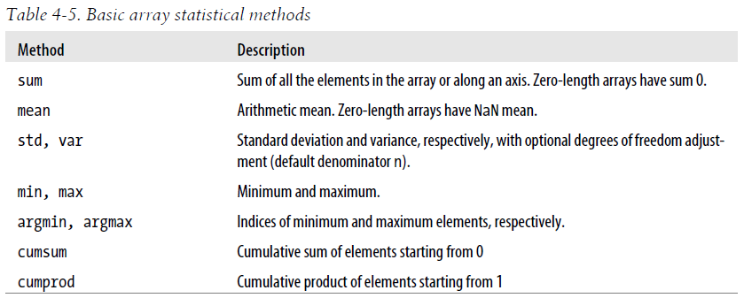

```python
# 기본 배열 통계 메소드
Image(bpc.Table4_5)
```

```python
arr = np.random.randn(5, 4) # normally-distributed data
arr
```

```
array([[-1.79963418e+00, -2.41741050e-01, -4.81300589e-04,
         1.11442319e+00],
       [ 8.51110619e-01,  1.35406970e+00,  2.99457482e-01,
        -7.66984989e-01],
       [-7.33362863e-01,  9.68395779e-01,  5.26164890e-01,
        -1.28748549e-01],
       [-8.82654609e-01,  7.16668933e-01,  8.29814721e-01,
        -3.97286300e-01],
       [ 3.92104272e-01,  1.16077239e+00,  3.91279892e-01,
        -9.86459835e-01]])
```

```python
arr.mean()
```

```
0.13334540965823224
```

```python
np.mean(arr)
```

```
0.13334540965823224
```

```python
arr.sum()
```

```
2.666908193164645
```

```python
arr.mean(axis=1)
```

```
array([-0.23185834,  0.4344132 ,  0.15811231,  0.06663569,  0.23942418])
```

```python
arr.sum(0)
```

```
array([-2.17243676,  3.95816576,  2.04623568, -1.16505649])
```

```python
arr = np.array([[0, 1, 2], [3, 4, 5], [6, 7, 8]])
arr
```

```
array([[0, 1, 2],
       [3, 4, 5],
       [6, 7, 8]])
```

```python
# 각 원소의 누적 합
arr.cumsum(0)
```

```
array([[ 0,  1,  2],
       [ 3,  5,  7],
       [ 9, 12, 15]], dtype=int32)
```

```python
# 각 원소의 누적 곱
arr.cumprod(1)
```

```
array([[  0,   0,   0],
       [  3,  12,  60],
       [  6,  42, 336]], dtype=int32)
```

### Methods for boolean arrays

> 불리언 배열을 위한 메소드
> - 불리언 값은 1(True), 0(False)으로 취급
> - 따라서 불리언 배열에 대한 sum 메소드를 실행하면 True인 원소의 개수를 반환
> - any() : 하나 이상의 True 값이 있는 지 검사
> - all() : 모든 원소가 True 인지 검사

```python
arr = randn(100)
arr
```

```
array([-1.24149542, -1.02127506, -0.87618427, -0.95158736,  0.55545275,
       -0.75297629, -0.24583741,  1.00704552,  0.96911502,  0.01463916,
        0.17133956,  0.04051931, -0.32611334,  2.65382016,  0.63240819,
       -0.92415387,  1.41348502, -2.04447104,  0.12205103,  0.79277783,
       -0.29731199,  0.68658004, -0.20184487,  0.89501475,  1.34480051,
       -0.94909243,  1.21420701, -0.2838071 , -0.73097235,  2.3190442 ,
        0.2002396 , -0.09344463,  0.19830459, -1.09622401,  1.10917684,
        1.36123654, -0.5039113 , -0.39171835, -1.51115037,  0.23907401,
       -1.35478769,  0.20795819,  1.82161534,  0.9352784 ,  0.24954201,
       -0.41510011, -1.21892228, -2.66854612,  0.65621157,  1.24445424,
        0.56385286, -0.42930899, -0.0770157 , -0.12068849, -0.07540068,
        0.08982094, -0.37582048, -0.67916893, -1.13957448, -0.5042455 ,
       -1.29284267, -0.61214073,  0.17744587, -0.85533064,  1.25642545,
       -1.15060851,  1.35050917, -0.52589113,  0.29529963,  1.66194551,
        0.97892576, -0.41479805, -0.42580092,  0.06373082,  1.07439609,
        0.53779498,  0.32008681, -0.93186037, -1.59691233,  0.72568526,
       -0.77963528,  0.36964804,  0.48648335,  0.0477427 ,  0.02404451,
        0.07625964, -0.23314247, -0.17315208,  0.40458011,  1.16699367,
        0.28814843, -0.24207877,  1.7207205 , -0.3872436 , -1.0762568 ,
       -1.05046971, -1.61903413,  0.51961355, -0.31708799, -0.83023337])
```

```python
(arr > 0).sum() # Number of positive values
```

```
50
```

```python
bools = np.array([False, False, True, False])
bools
```

```
array([False, False,  True, False])
```

```python
bools.any()
```

```
True
```

```python
bools.all()
```

```
False
```

### Sorting

```python
arr = randn(8)
arr
```

```
array([ 0.41090104,  0.27218999,  0.3621    , -0.06856613,  0.21490359,
       -0.81346477,  0.60907085, -0.67235363])
```

```python
arr.sort()
arr
```

```
array([-0.81346477, -0.67235363, -0.06856613,  0.21490359,  0.27218999,
        0.3621    ,  0.41090104,  0.60907085])
```

```python
arr = randn(5, 3)
arr
```

```
array([[ 0.56730341, -0.19510148, -1.15219084],
       [-1.69456828, -0.79015705, -1.01733994],
       [ 0.80139323, -0.38238078, -1.05660473],
       [-1.20183217, -1.43680556,  1.33015881],
       [ 1.79929915, -0.42878364, -1.14092181]])
```

```python
arr.sort(1)
arr
```

```
array([[-1.15219084, -0.19510148,  0.56730341],
       [-1.69456828, -1.01733994, -0.79015705],
       [-1.05660473, -0.38238078,  0.80139323],
       [-1.43680556, -1.20183217,  1.33015881],
       [-1.14092181, -0.42878364,  1.79929915]])
```

```python
large_arr = randn(1000)
large_arr
```

```
array([ 1.55343700e+00,  7.72590309e-01, -1.33932199e+00, -9.30998651e-01,
       -2.03078615e+00,  2.20308139e-01,  9.45298932e-01, -5.71174355e-01,
       -8.99359748e-01, -1.54312856e+00,  2.17235207e+00, -1.37283075e+00,
       -8.08982208e-01,  1.64920679e-01,  1.26481492e-01, -3.31285450e-01,
       -1.03520433e-01,  4.04618463e-02, -3.60805242e-01,  1.20547673e-01,
        2.25049512e+00,  3.20682362e-01,  4.56729623e-01, -3.92342825e+00,
       -2.22478917e-01, -8.25018550e-01,  1.06598635e+00,  8.49979228e-01,
        5.59834059e-01, -3.64614874e-01,  2.03329861e+00, -4.55303192e-01,
       -4.03021685e-03, -7.33444568e-01,  1.16088768e+00,  1.07686524e+00,
       -4.54756036e-02,  2.82411574e-01, -1.11098499e+00, -1.60413278e+00,
        5.54459603e-01,  3.56766636e-01, -1.77117859e-01,  5.56301025e-01,
        9.15246250e-01, -1.62789417e-01, -5.14148838e-02,  5.44120588e-02,
       -3.66975535e-01, -1.78212698e+00,  2.42927616e-01,  1.86931832e-01,
        6.92537155e-01, -7.97357366e-01, -7.71057173e-01,  2.41239179e+00,
        9.73497788e-01, -1.17651241e+00,  7.11116353e-01,  1.03894481e+00,
       -1.83543325e+00,  1.23389967e+00, -3.35566107e-01, -1.05644576e+00,
       -6.01485770e-01,  2.18889795e+00, -3.24299062e+00, -4.72179733e-01,
       -8.12199984e-01,  2.43808386e-02, -5.46630315e-01,  2.92639907e-01,
       -5.12030196e-01,  1.46423415e+00,  2.01951153e+00,  3.94253602e-01,
       -1.44432027e+00, -8.26404968e-01, -9.63066646e-02,  4.19702878e-01,
        2.23158441e+00, -1.49137583e+00,  2.51147311e-01,  1.72362962e+00,
       -4.73514947e-01, -5.28551920e-01,  2.90673957e-01,  1.15456482e+00,
        1.35260071e+00,  9.00413203e-01, -9.10099205e-01, -2.09501786e+00,
        4.25465808e-01,  2.53086489e-01,  1.26447070e+00,  5.48838762e-01,
       -6.64081947e-01,  3.66481400e-01,  7.98320987e-01, -9.45926767e-01,
       -3.27773383e-01,  6.53061026e-01,  2.09612572e-01,  1.50968740e+00,
        5.87090751e-01, -4.74245001e-01,  1.21569938e+00,  5.33152559e-01,
       -1.24779954e+00, -1.47634103e+00, -4.01114357e-01,  8.74632348e-01,
       -2.11476436e+00, -2.19393109e-01, -7.76532834e-01, -8.26847479e-01,
       -5.49226306e-01, -8.62723715e-01, -3.16364799e-01, -1.33690261e-01,
        5.21203494e-01,  1.78211190e+00,  8.47312861e-01,  8.52992416e-01,
       -1.10953344e+00,  1.42987796e+00, -1.12366652e+00,  4.36404438e-02,
        1.26726723e+00,  8.07952107e-03,  1.56023814e-01, -3.04974853e+00,
        8.06671068e-01,  1.32338713e+00, -1.35244784e+00,  1.34278382e+00,
        4.56973250e-03,  8.02942123e-01,  3.72780953e-01,  1.56881363e+00,
        1.23380230e+00,  1.41861978e-01, -6.24024631e-01, -4.12218709e-01,
       -1.84995316e-01, -1.60844310e+00, -1.07560026e+00,  7.59716943e-01,
        1.11977584e+00, -1.89234201e+00, -2.61649704e-01, -3.63922129e-01,
        9.07839421e-01,  4.91462765e-01, -1.22265563e+00, -9.59198902e-01,
        6.36995875e-01, -1.74016318e+00,  1.14871865e+00, -1.13972701e-01,
```

[output cut: 195 more lines]

```
       -5.52345738e-01, -2.06075329e+00, -1.52636382e-01,  9.20883021e-02,
       -2.05115885e+00,  2.71467940e+00, -1.04741927e+00,  3.69192987e-01,
        2.76695309e-01, -6.29883757e-01, -2.02460171e-01,  1.17910453e+00,
       -8.73724784e-01,  1.50745620e+00,  3.64276837e-01,  4.58603114e-01,
       -3.73421544e-01,  1.04056723e-01, -6.29185988e-03,  3.35008535e-01,
        1.82213102e+00,  1.85498329e-01, -1.45640403e-02,  1.83024138e+00,
       -3.34117269e-01, -1.59164789e+00,  1.54184272e+00, -7.51501103e-02,
       -1.03965255e+00,  1.78232243e+00, -8.44685080e-01,  7.98228741e-01,
       -9.12755208e-01, -9.88459977e-01, -5.06701520e-01, -3.03235484e-01,
        1.99941149e-01,  1.86301839e+00, -2.97163543e-01, -1.22052252e-01,
       -4.13733675e-01, -2.47744568e-01,  8.58112841e-01, -1.37260026e+00,
        6.66450065e-01, -2.70204275e-02,  6.58967887e-01, -7.13276065e-01,
        1.10925779e+00,  1.78418083e-01,  3.53797536e-01, -1.09312829e+00,
        1.66097236e+00,  2.53227231e-01, -1.44232900e+00,  6.14303108e-01,
        8.74059874e-01,  7.13050784e-01, -1.53177079e+00,  2.38798602e-01])
```

```python
large_arr.sort()
large_arr
```

```
array([-3.92342825e+00, -3.24299062e+00, -3.04974853e+00, -2.74031306e+00,
       -2.65159478e+00, -2.64064591e+00, -2.58445401e+00, -2.57340485e+00,
       -2.51520787e+00, -2.41034641e+00, -2.31878424e+00, -2.23502258e+00,
       -2.23409335e+00, -2.21602631e+00, -2.19777852e+00, -2.13433702e+00,
       -2.11476436e+00, -2.11336488e+00, -2.09501786e+00, -2.06075329e+00,
       -2.05418897e+00, -2.05115885e+00, -2.03078615e+00, -1.93054226e+00,
       -1.91610451e+00, -1.90689617e+00, -1.90673578e+00, -1.90592803e+00,
       -1.89748043e+00, -1.89347669e+00, -1.89234201e+00, -1.88525663e+00,
       -1.83543325e+00, -1.80865923e+00, -1.78212698e+00, -1.76130962e+00,
       -1.74334581e+00, -1.74016318e+00, -1.70917248e+00, -1.69802774e+00,
       -1.69761923e+00, -1.68228455e+00, -1.67981221e+00, -1.66394651e+00,
       -1.66185985e+00, -1.65809215e+00, -1.65005580e+00, -1.60844310e+00,
       -1.60456489e+00, -1.60413278e+00, -1.59567217e+00, -1.59164789e+00,
       -1.59101524e+00, -1.58650865e+00, -1.57452192e+00, -1.57420860e+00,
       -1.56762267e+00, -1.54939895e+00, -1.54312856e+00, -1.53493963e+00,
       -1.53177079e+00, -1.52796557e+00, -1.52635702e+00, -1.52531951e+00,
       -1.51922554e+00, -1.51655453e+00, -1.50026686e+00, -1.49420672e+00,
       -1.49137583e+00, -1.48656222e+00, -1.47634103e+00, -1.46530516e+00,
       -1.46140499e+00, -1.45117543e+00, -1.44726356e+00, -1.44432027e+00,
       -1.44308666e+00, -1.44232900e+00, -1.43839400e+00, -1.42207532e+00,
       -1.41113118e+00, -1.39594099e+00, -1.39162093e+00, -1.38707486e+00,
       -1.38427802e+00, -1.38422509e+00, -1.38399980e+00, -1.38102982e+00,
       -1.37283075e+00, -1.37260026e+00, -1.36018357e+00, -1.35749388e+00,
       -1.35244784e+00, -1.35087587e+00, -1.34809953e+00, -1.33932199e+00,
       -1.33588424e+00, -1.32498732e+00, -1.31519114e+00, -1.31229181e+00,
       -1.30888241e+00, -1.30059695e+00, -1.29965635e+00, -1.28887423e+00,
       -1.27744486e+00, -1.27633509e+00, -1.27109340e+00, -1.26895459e+00,
       -1.26166552e+00, -1.25259049e+00, -1.24779954e+00, -1.24691355e+00,
       -1.22265563e+00, -1.21659195e+00, -1.20316232e+00, -1.19308576e+00,
       -1.19139339e+00, -1.17921031e+00, -1.17651241e+00, -1.17649993e+00,
       -1.17348149e+00, -1.17139086e+00, -1.17042199e+00, -1.16990935e+00,
       -1.16102157e+00, -1.15597150e+00, -1.15078776e+00, -1.14415721e+00,
       -1.14033935e+00, -1.13153147e+00, -1.12423238e+00, -1.12366652e+00,
       -1.12082515e+00, -1.11098499e+00, -1.10981943e+00, -1.10953344e+00,
       -1.10321784e+00, -1.10250921e+00, -1.09312829e+00, -1.09133375e+00,
       -1.08512420e+00, -1.07996529e+00, -1.07828860e+00, -1.07560026e+00,
       -1.07495121e+00, -1.07379534e+00, -1.06099300e+00, -1.05644576e+00,
       -1.04741927e+00, -1.04410985e+00, -1.03965255e+00, -1.02222733e+00,
       -1.02043652e+00, -1.01348275e+00, -1.01254678e+00, -1.01189294e+00,
       -1.00983433e+00, -1.00699248e+00, -1.00518668e+00, -1.00417689e+00,
```

[output cut: 195 more lines]

```
        1.56881363e+00,  1.62295972e+00,  1.62613154e+00,  1.62768983e+00,
        1.64391688e+00,  1.64579956e+00,  1.66097236e+00,  1.66501285e+00,
        1.68343256e+00,  1.69550360e+00,  1.70200762e+00,  1.72362962e+00,
        1.73476996e+00,  1.74131646e+00,  1.75560787e+00,  1.75889035e+00,
        1.76390617e+00,  1.77172470e+00,  1.78211190e+00,  1.78232243e+00,
        1.80276578e+00,  1.81087406e+00,  1.82213102e+00,  1.83024138e+00,
        1.85771693e+00,  1.86301839e+00,  1.87346505e+00,  1.91031802e+00,
        1.91393990e+00,  1.91667374e+00,  1.92024707e+00,  1.92064838e+00,
        1.92468672e+00,  1.92656207e+00,  1.95841450e+00,  1.96776415e+00,
        1.99590397e+00,  2.00031717e+00,  2.01951153e+00,  2.03329861e+00,
        2.07207327e+00,  2.13721931e+00,  2.14013105e+00,  2.16519394e+00,
        2.17235207e+00,  2.18889795e+00,  2.23158441e+00,  2.23258336e+00,
        2.25049512e+00,  2.27439222e+00,  2.28678682e+00,  2.30500714e+00,
        2.41239179e+00,  2.46138195e+00,  2.52616219e+00,  2.57642678e+00,
        2.71467940e+00,  2.89261527e+00,  2.99530384e+00,  3.19007377e+00])
```

```python
large_arr[int(0.05 * len(large_arr))] # 5% quantile
```

```
-1.5956721742609152
```

### Unique and other set logic

> 집합 함수

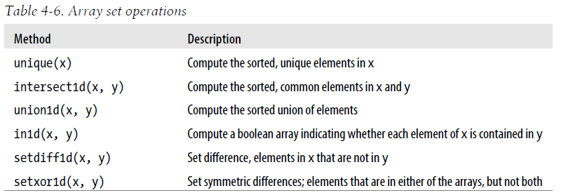

```python
# 배열 집합연산
Image(bpc.Table4_6)
```

```python
names = np.array(['Bob', 'Joe', 'Will', 'Bob', 'Will', 'Joe', 'Joe'])
names
```

```
array(['Bob', 'Joe', 'Will', 'Bob', 'Will', 'Joe', 'Joe'], dtype='<U4')
```

```python
np.unique(names)
```

```
array(['Bob', 'Joe', 'Will'], dtype='<U4')
```

```python
ints = np.array([3, 3, 3, 2, 2, 1, 1, 4, 4])
```

```python
np.unique(ints)
```

```
array([1, 2, 3, 4])
```

```python
sorted(set(names))
```

```
['Bob', 'Joe', 'Will']
```

```python
values = np.array([6, 0, 0, 3, 2, 5, 6])
values
```

```
array([6, 0, 0, 3, 2, 5, 6])
```

```python
np.in1d(values, [2, 3, 6])
```

```
array([ True, False, False,  True,  True, False,  True])
```

The BigpyCraft find the information to design valuable society with Technology & Craft.

< The End >